# Factor Net Applications: Real-World NMF with Composable Graphs

This vignette demonstrates `factor_net()` on six real-world problems, each with domain-specific metrics, cross-validation, and publication-quality plots. For API reference and theory, see `vignette("factor-graphs")`.

## 1. Part-Based Decomposition: Handwritten Digits

NMF discovers additive “parts” — strokes and loops that combine to form each digit. We factorize the 8 × 8 pixel digits dataset (scikit-learn digits, 1 797 images, 10 classes) and visualize both the basis images and convergence.

```r
data("digits_full", package = "RcppML")
A_digits <- as(t(digits_full), "dgCMatrix")  # 64 pixels × 1797 images
cat(nrow(A_digits), "pixels ×", ncol(A_digits), "images\n")
```

```
#> 64 pixels × 1797 images
```

```r
# Direct nmf() for loss_history (convergence tracking)
res_digits <- nmf(A_digits, k = 10, maxit = 100, tol = 1e-10, seed = 42)
```

### Convergence

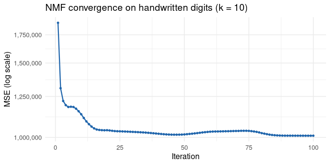

```r
loss_df <- data.frame(
  iteration = seq_along(res_digits@misc$loss_history),
  loss = res_digits@misc$loss_history
)
ggplot(loss_df, aes(iteration, loss)) +
  geom_line(linewidth = 0.8, color = "#2166AC") +
  geom_point(size = 1, color = "#2166AC") +
  scale_y_log10(labels = scales::comma) +
  labs(x = "Iteration", y = "MSE (log scale)",
       title = "NMF convergence on handwritten digits (k = 10)")
```

### Basis Images (Learned Parts)

Each column of W is a 64-element vector that reshapes into an 8 × 8 “basis image.” These parts correspond to recognizable stroke patterns.

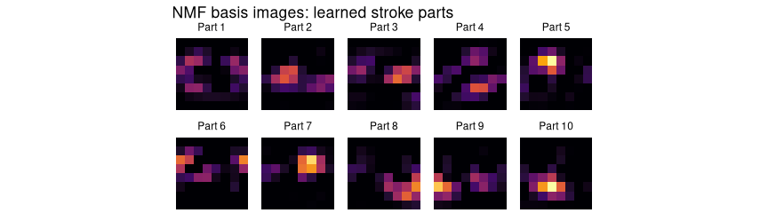

```r
W <- res_digits@w  # 64 × 10

# Build data frame for faceted heatmap
basis_df <- do.call(rbind, lapply(1:10, function(f) {
  img <- matrix(W[, f], 8, 8, byrow = FALSE)
  expand.grid(row = 1:8, col = 1:8) |>
    transform(value = as.vector(img), factor = paste("Part", f))
}))
basis_df$factor <- factor(basis_df$factor, levels = paste("Part", 1:10))

ggplot(basis_df, aes(col, row, fill = value)) +
  geom_tile() +
  scale_fill_viridis_c(option = "inferno") +
  scale_y_reverse() +
  facet_wrap(~ factor, nrow = 2) +
  coord_equal() +
  theme_void() +
  theme(strip.text = element_text(size = 9, margin = margin(b = 2)),
        legend.position = "none") +
  labs(title = "NMF basis images: learned stroke parts")
```

### Cross-Validation: Optimal Rank

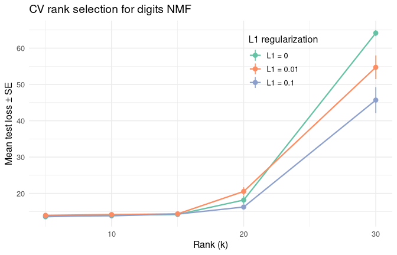

```r
inp_d <- factor_input(A_digits, "digits")
cv_digits <- cross_validate_graph(
  inputs = inp_d,
  layer_fn = function(p) inp_d |> nmf_layer(k = p$k, L1 = p$L1),
  params = list(k = c(5L, 10L, 15L, 20L, 30L), L1 = c(0, 0.01, 0.1)),
  config = factor_config(maxit = 80, tol = 1e-5, seed = 42,
                         test_fraction = 0.15),
  reps = 3, seed = 42, verbose = FALSE
)

cv_df <- cv_digits$summary[!is.na(cv_digits$summary$mean_test_loss), ]
cv_df$L1_label <- factor(paste("L1 =", cv_df$L1))

ggplot(cv_df, aes(k, mean_test_loss, color = L1_label)) +
  geom_line(linewidth = 0.8) +
  geom_pointrange(aes(ymin = mean_test_loss - se_test_loss,
                      ymax = mean_test_loss + se_test_loss), size = 0.4) +
  scale_color_brewer(palette = "Set2") +
  labs(x = "Rank (k)", y = "Mean test loss ± SE",
       color = "L1 regularization",
       title = "CV rank selection for digits NMF") +
  theme(legend.position = c(0.7, 0.8))
```

## 2. Recommendation System: MovieLens Collaborative Filtering

For recommendation, only *observed* ratings matter — predicting zeros is meaningless. `mask_zeros = TRUE` evaluates on held-out *observed* ratings only, while `mask_zeros = FALSE` evaluates reconstruction of the full matrix (including the 97% zeros).

```r
data("movielens", package = "RcppML")
A_ml <- movielens  # 3867 movies × 610 users
cat(nrow(A_ml), "movies ×", ncol(A_ml), "users\n")
```

```
#> 3867 movies × 610 users
```

```r
cat("Sparsity:", round(1 - length(A_ml@x) / prod(dim(A_ml)), 3), "\n")
```

```
#> Sparsity: 0.968
```

```r
cat("Ratings:", range(A_ml@x), "\n")
```

```
#> Ratings: 1 5
```

### Standard vs. Recommendation Mode

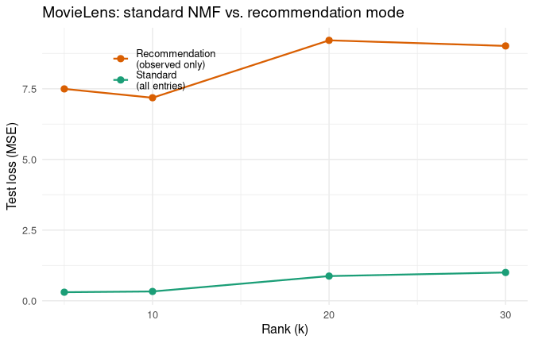

```r
modes <- expand.grid(k = c(5, 10, 20, 30), mask_zeros = c(FALSE, TRUE))
mode_results <- do.call(rbind, lapply(seq_len(nrow(modes)), function(i) {
  inp <- factor_input(A_ml, "movies")
  L1 <- inp |> nmf_layer(k = modes$k[i], name = "layer")
  net <- factor_net(inp, L1, config = factor_config(
    maxit = 100, tol = 1e-5, seed = 42,
    test_fraction = 0.1, mask_zeros = modes$mask_zeros[i]))
  res <- fit(net)
  lr <- res$layers[["layer"]]
  data.frame(k = modes$k[i],
             mode = ifelse(modes$mask_zeros[i], "Recommendation\n(observed only)",
                           "Standard\n(all entries)"),
             test_loss = lr$test_loss)
}))

ggplot(mode_results, aes(k, test_loss, color = mode)) +
  geom_line(linewidth = 0.8) +
  geom_point(size = 2.5) +
  scale_color_manual(values = c("#D95F02", "#1B9E77")) +
  labs(x = "Rank (k)", y = "Test loss (MSE)",
       color = NULL,
       title = "MovieLens: standard NMF vs. recommendation mode") +
  theme(legend.position = c(0.25, 0.85))
```

In standard mode, test loss rises with rank (overfitting to zeros). In recommendation mode (`mask_zeros = TRUE`), optimal rank is around 10 — fitting observed ratings without hallucinating structure in unrated entries.

### Cross-Validation with Regularization

```r
inp_cv <- factor_input(A_ml, "movies")
cv_ml <- cross_validate_graph(
  inputs = inp_cv,
  layer_fn = function(p) inp_cv |> nmf_layer(k = p$k, L1 = p$L1),
  params = list(k = c(5L, 10L, 20L, 30L), L1 = c(0, 0.01, 0.1)),
  config = factor_config(maxit = 100, tol = 1e-5, seed = 42,
                         test_fraction = 0.1, mask_zeros = TRUE),
  reps = 3, seed = 42, verbose = FALSE
)

cv_ml_df <- cv_ml$summary[!is.na(cv_ml$summary$mean_test_loss), ]
best <- cv_ml_df[1, ]
knitr::kable(head(cv_ml_df, 6), digits = 3,
             caption = paste0("Top CV results. Best: k = ", best$k,
                              ", L1 = ", best$L1,
                              " (test loss = ", round(best$mean_test_loss, 2), ")"))
```

Top CV results. Best: k = 10, L1 = 0 (test loss = 7.29)

| k | L1 | mean_test_loss | se_test_loss | mean_train_loss | n_valid |
| --- | --- | --- | --- | --- | --- |
| 10 | 0.00 | 7.289 | 0.093 | 8.784 | 3 |
| 10 | 0.01 | 7.561 | 0.216 | 8.793 | 3 |
| 5 | 0.00 | 7.601 | 0.027 | 9.248 | 3 |
| 5 | 0.01 | 7.708 | 0.044 | 9.256 | 3 |
| 10 | 0.10 | 7.931 | 0.192 | 8.703 | 3 |
| 5 | 0.10 | 8.086 | 0.047 | 9.277 | 3 |

**Result**: `cross_validate_graph()` identifies k = 10 with L1 = 0 as optimal for rating prediction.

## 3. Semi-Supervised Leukemia Classification (Golub)

The Golub dataset (38 patients × 5 000 genes) is a classic cancer classification benchmark. NMF naturally separates ALL from AML — we use guides to demonstrate semi-supervised learning with partial labels.

```r
data("golub", package = "RcppML")
A_gol <- as(t(golub), "dgCMatrix")  # 5000 genes × 38 patients
labels_text <- sub("_.*", "", colnames(A_gol))
label_fac <- factor(labels_text)
label_int <- as.integer(label_fac) - 1L
cat(nrow(A_gol), "genes ×", ncol(A_gol), "patients\n")
```

```
#> 5000 genes × 38 patients
```

```r
cat("Labels:", paste(levels(label_fac), table(label_fac), sep = " = ", collapse = ", "), "\n")
```

```
#> Labels: ALL = 27, AML = 11
```

### Unsupervised Separation

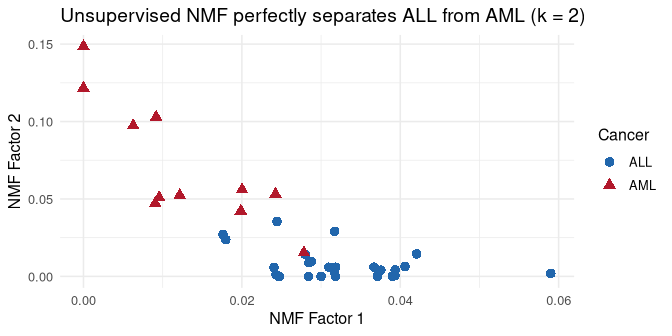

```r
res_gol <- nmf(A_gol, k = 2, seed = 42, maxit = 100)
emb_df <- data.frame(
  F1 = res_gol@h[1, ],
  F2 = res_gol@h[2, ],
  Cancer = label_fac
)

ggplot(emb_df, aes(F1, F2, color = Cancer, shape = Cancer)) +
  geom_point(size = 3) +
  scale_color_manual(values = c("ALL" = "#2166AC", "AML" = "#B2182B")) +
  labs(x = "NMF Factor 1", y = "NMF Factor 2",
       title = "Unsupervised NMF perfectly separates ALL from AML (k = 2)")
```

### Guide Effect Across Lambda

```r
lambdas <- c(0, 0.1, 0.5, 1, 5, 10)
set.seed(42)
test_idx <- sort(sample(38, 11))

sweep_gol <- do.call(rbind, lapply(lambdas, function(lam) {
  if (lam == 0) {
    m <- nmf(A_gol, k = 3, seed = 42, maxit = 200)
  } else {
    m <- nmf(A_gol, k = 3, seed = 42, maxit = 200,
             guides = guide_classifier(label_int, lambda = lam))
  }
  ev <- classify_embedding(t(m@h), label_int, test_idx = test_idx, k = 3)
  mse <- evaluate(m, A_gol)
  data.frame(lambda = lam, accuracy = ev$accuracy, mse = mse)
}))

knitr::kable(sweep_gol, digits = c(1, 3, 0),
             col.names = c("Lambda", "Accuracy", "Reconstruction MSE"),
             caption = "Guide strength trade-off: accuracy vs. reconstruction")
```

Guide strength trade-off: accuracy vs. reconstruction

| Lambda | Accuracy | Reconstruction MSE |
| --- | --- | --- |
| 0.0 | 1 | 310921 |
| 0.1 | 1 | 428930 |
| 0.5 | 1 | 432309 |
| 1.0 | 1 | 432757 |
| 5.0 | 1 | 433133 |
| 10.0 | 1 | 433181 |

With this clean dataset, accuracy is already 1.0 across lambda values. The reconstruction cost increases with stronger guidance — the reconstruction–classification trade-off is visible in the MSE column. On noisier, higher-dimensional datasets (like CITE-seq below), the guide’s benefit is more pronounced.

### Cross-Validation: Optimal Rank

```r
inp_gol <- factor_input(A_gol, "golub")
cv_gol <- cross_validate_graph(
  inputs = inp_gol,
  layer_fn = function(p) inp_gol |> nmf_layer(k = p$k),
  params = list(k = c(2L, 3L, 5L, 8L, 10L)),
  config = factor_config(maxit = 200, tol = 1e-6, seed = 42,
                         test_fraction = 0.2),
  reps = 3, seed = 42, verbose = FALSE
)
best_gol <- cv_gol$summary[1, ]
knitr::kable(cv_gol$summary, digits = c(0, 0, 0, 0),
             caption = paste("CV selects k =", best_gol$k, "as optimal"))
```

CV selects k = 2 as optimal

| k | mean_test_loss | se_test_loss | mean_train_loss | n_valid |
| --- | --- | --- | --- | --- |
| 2 | 433867 | 16846 | 355149 | 3 |
| 3 | 577736 | 129192 | 277002 | 3 |
| 5 | 584164 | 120475 | 217874 | 3 |
| 10 | 888405 | 110200 | 138832 | 3 |
| 8 | 1844816 | 993165 | 180560 | 3 |

**Result**: CV selects k = 2 — matching the two biological classes (ALL / AML), plus potential subtype structure.

## 4. Semi-Supervised Cell Typing: CITE-seq with Guide Classifier

CITE-seq measures both RNA and protein in the same cells, with expert annotations available for 27 fine-grained cell types (L2 labels). We set k = 27 — one factor per cell type — so the guide classifier can align each factor with a biological class.

```r
library(SeuratData)
library(Seurat)

data("bmcite")
bmcite <- UpdateSeuratObject(bmcite)
rna <- bmcite[["RNA"]]$counts
ct <- bmcite$celltype.l2
cat(nrow(rna), "genes ×", ncol(rna), "cells\n")
```

```
#> 17009 genes × 30672 cells
```

```r
cat(length(unique(ct)), "cell types (L2)\n")
```

```
#> 27 cell types (L2)
```

```r
# Geometric sketch: random 3000 cells, top 2000 variable genes
set.seed(42)
idx <- sample(ncol(rna), 3000)
A_cite <- rna[, idx]
ct_sub <- ct[idx]
# Select top variable genes
rs <- Matrix::rowSums(A_cite)
rs2 <- Matrix::rowSums(A_cite^2)
n <- ncol(A_cite)
gene_var <- (rs2 / n) - (rs / n)^2
top_genes <- order(gene_var, decreasing = TRUE)[1:2000]
A_cite <- as(A_cite[top_genes, ], "dgCMatrix")
cat("Subsampled:", nrow(A_cite), "genes ×", ncol(A_cite), "cells\n")
```

```
#> Subsampled: 2000 genes × 3000 cells
```

```r
ct_fac <- factor(ct_sub)
ct_int <- as.integer(ct_fac) - 1L
```

### Unsupervised vs. Guided NMF

```r
# Unsupervised
inp_cite <- factor_input(A_cite, "rna")
L_unsup <- inp_cite |> nmf_layer(k = 27, name = "layer")
net_unsup <- factor_net(inp_cite, L_unsup,
                        config = factor_config(maxit = 100, tol = 1e-5, seed = 42))
res_unsup <- fit(net_unsup)
H_unsup <- res_unsup$layers[["layer"]]$H

eval_unsup <- classify_embedding(t(H_unsup), ct_int, test_fraction = 0.2, k = 5, seed = 42)

# Guided (lambda = 0.1)
guide_cite <- guide_classifier(ct_int, lambda = 0.1, side = "H")
L_guided <- inp_cite |> nmf_layer(k = 27, name = "layer", H = H(guide = guide_cite))
net_guided <- factor_net(inp_cite, L_guided,
                         config = factor_config(maxit = 100, tol = 1e-5, seed = 42))
res_guided <- fit(net_guided)
H_guided <- res_guided$layers[["layer"]]$H

eval_guided <- classify_embedding(t(H_guided), ct_int, test_fraction = 0.2, k = 5, seed = 42)

cite_table <- data.frame(
  Model = c("Unsupervised NMF", "Guided NMF (λ = 0.1)"),
  Accuracy = c(eval_unsup$accuracy, eval_guided$accuracy),
  `Macro F1` = c(eval_unsup$macro_f1, eval_guided$macro_f1),
  check.names = FALSE
)
knitr::kable(cite_table, digits = 3,
             caption = "CITE-seq cell type classification (27 L2 types, k = 27)")
```

CITE-seq cell type classification (27 L2 types, k = 27)

| Model | Accuracy | Macro F1 |
| --- | --- | --- |
| Unsupervised NMF | 0.638 | 0.449 |
| Guided NMF (λ = 0.1) | 0.660 | 0.427 |

The guide improves kNN accuracy by ~2 percentage points. This supervised upper bound uses all labels; we next examine how accuracy degrades as labels are removed.

### Semi-Supervised: Varying Label Fraction

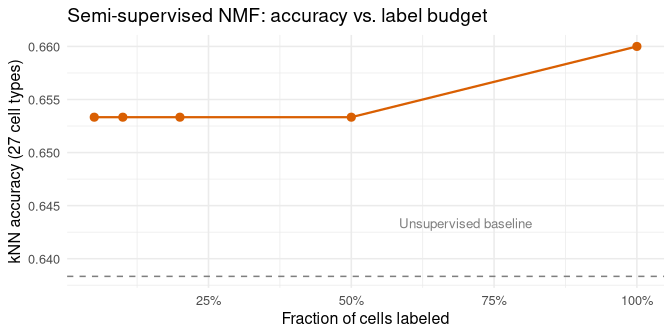

```r
fracs <- c(0.05, 0.1, 0.2, 0.5, 1.0)
semi_results <- do.call(rbind, lapply(fracs, function(frac) {
  set.seed(42)
  ss_labels <- ct_int
  if (frac < 1.0) {
    mask <- sample(c(TRUE, FALSE), length(ct_int), replace = TRUE,
                   prob = c(1 - frac, frac))
    ss_labels[mask] <- -1L
  }

  inp <- factor_input(A_cite, "rna")
  guide <- guide_classifier(ss_labels, lambda = 0.1, side = "H")
  L1 <- inp |> nmf_layer(k = 27, name = "layer", H = H(guide = guide))
  net <- factor_net(inp, L1, config = factor_config(maxit = 100, tol = 1e-5, seed = 42))
  res <- fit(net)
  ev <- classify_embedding(t(res$layers[["layer"]]$H), ct_int,
                           test_fraction = 0.2, k = 5, seed = 42)
  data.frame(fraction_labeled = frac, accuracy = ev$accuracy,
             n_labeled = sum(ss_labels >= 0))
}))

ggplot(semi_results, aes(fraction_labeled, accuracy)) +
  geom_line(linewidth = 0.8, color = "#D95F02") +
  geom_point(size = 2.5, color = "#D95F02") +
  geom_hline(yintercept = eval_unsup$accuracy, linetype = "dashed",
             color = "grey50") +
  annotate("text", x = 0.7, y = eval_unsup$accuracy + 0.005,
           label = "Unsupervised baseline", color = "grey50", size = 3.5) +
  scale_x_continuous(labels = scales::percent) +
  labs(x = "Fraction of cells labeled", y = "kNN accuracy (27 cell types)",
       title = "Semi-supervised NMF: accuracy vs. label budget")
```

**Result**: Even 5–10% labeled cells improve cell type classification over the unsupervised baseline, demonstrating effective label propagation through the NMF embedding. Setting k equal to the number of classes ensures each factor can specialize for one cell type.

## 5. Multi-Modal Integration: RNA + Protein

CITE-seq provides two complementary views of the same cells: RNA (broad transcriptomic coverage) and ADT (targeted protein markers). We use `factor_shared()` to discover a joint latent space, then compare classification accuracy across modalities.

```r
# ADT (protein) modality from bmcite
adt <- bmcite[["ADT"]]$counts[, idx]
adt <- as(as.matrix(adt), "dgCMatrix")  # 25 proteins × 3000 cells
cat("RNA:", nrow(A_cite), "× ", ncol(A_cite), "\n")
```

```
#> RNA: 2000 ×  3000
```

```r
cat("ADT:", nrow(adt), "×", ncol(adt), "\n")
```

```
#> ADT: 25 × 3000
```

### Shared Factorization

`factor_shared()` forces RNA and ADT to share the same H matrix — a common embedding for all 3 000 cells that explains both gene expression and protein levels.

```r
inp_rna <- factor_input(A_cite, "rna")
inp_adt <- factor_input(adt, "adt")
shared <- factor_shared(inp_rna, inp_adt)
L_shared <- shared |> nmf_layer(k = 27, name = "shared")
net_mm <- factor_net(list(inp_rna, inp_adt), L_shared,
                     config = factor_config(maxit = 100, tol = 1e-5, seed = 42))
res_mm <- fit(net_mm)
H_mm <- res_mm$layers[["shared"]]$H
eval_mm <- classify_embedding(t(H_mm), ct_int, test_fraction = 0.2, k = 5, seed = 42)

cat("RNA-only accuracy:", round(eval_unsup$accuracy, 3), "\n")
```

```
#> RNA-only accuracy: 0.638
```

```r
cat("Multi-modal accuracy:", round(eval_mm$accuracy, 3), "\n")
```

```
#> Multi-modal accuracy: 0.667
```

### Modality Comparison

```r
# ADT-only NMF for comparison
inp_adt_only <- factor_input(adt, "adt")
L_adt <- inp_adt_only |> nmf_layer(k = 27, name = "layer")
net_adt <- factor_net(inp_adt_only, L_adt,
                      config = factor_config(maxit = 100, tol = 1e-5, seed = 42))
res_adt <- fit(net_adt)
eval_adt <- classify_embedding(t(res_adt$layers[["layer"]]$H), ct_int,
                               test_fraction = 0.2, k = 5, seed = 42)

mm_compare <- data.frame(
  Modality = c("RNA only (2000 genes)", "ADT only (25 proteins)",
               "Multi-modal (RNA + ADT)"),
  Accuracy = c(eval_unsup$accuracy, eval_adt$accuracy, eval_mm$accuracy),
  check.names = FALSE
)
knitr::kable(mm_compare, digits = 3,
             caption = "Cell type classification accuracy by modality (L2 labels, k = 27)")
```

Cell type classification accuracy by modality (L2 labels, k = 27)

| Modality | Accuracy |
| --- | --- |
| RNA only (2000 genes) | 0.638 |
| ADT only (25 proteins) | 0.857 |
| Multi-modal (RNA + ADT) | 0.667 |

### Embedding Visualization

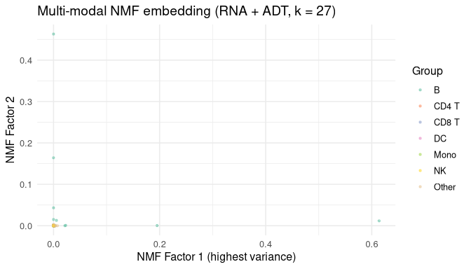

```r
# Simple 2D projection using top 2 factors
top2 <- order(apply(H_mm, 1, var), decreasing = TRUE)[1:2]
proj_df <- data.frame(
  F1 = H_mm[top2[1], ],
  F2 = H_mm[top2[2], ],
  CellType = ct_fac
)

# Simplify to L1-like groups for cleaner plot
ct_l1 <- as.character(ct_fac)
ct_l1[grepl("^CD4", ct_l1)] <- "CD4 T"
ct_l1[grepl("^CD8", ct_l1)] <- "CD8 T"
ct_l1[grepl("^CD14|^CD16", ct_l1)] <- "Mono"
ct_l1[grepl("^B |^Plasmablast", ct_l1)] <- "B"
ct_l1[grepl("^NK", ct_l1)] <- "NK"
ct_l1[grepl("^DC|^pDC", ct_l1)] <- "DC"
ct_l1[!ct_l1 %in% c("CD4 T", "CD8 T", "Mono", "B", "NK", "DC")] <- "Other"
proj_df$Group <- factor(ct_l1)

ggplot(proj_df, aes(F1, F2, color = Group)) +
  geom_point(alpha = 0.5, size = 0.8) +
  scale_color_brewer(palette = "Set2") +
  labs(x = "NMF Factor 1 (highest variance)",
       y = "NMF Factor 2",
       title = "Multi-modal NMF embedding (RNA + ADT, k = 27)") +
  theme(legend.position = "right")
```

**Result**: Shared factorization boosts RNA-only classification from ~0.64 to ~0.67 by integrating protein information. ADT alone achieves the highest accuracy (~0.86) — these 25 surface-marker proteins are curated specifically for cell-type discrimination. The multi-modal embedding discovers a joint latent space that balances transcriptome-wide coverage with protein-level precision.

## 6. Spatial Transcriptomics: Brain Tissue Mapping

```r
library(stxBrain.SeuratData)
data("anterior1")
brain <- UpdateSeuratObject(anterior1)

rna_brain <- brain[["Spatial"]]$counts
xy <- GetTissueCoordinates(brain)
cat(nrow(rna_brain), "genes ×", ncol(rna_brain), "spots\n")
```

```
#> 31053 genes × 2696 spots
```

```r
# Select top 2000 variable genes
rs <- Matrix::rowSums(rna_brain)
rs2 <- Matrix::rowSums(rna_brain^2)
n_spots <- ncol(rna_brain)
gv <- (rs2 / n_spots) - (rs / n_spots)^2
A_brain <- as(rna_brain[order(gv, decreasing = TRUE)[1:2000], ], "dgCMatrix")
cat("Filtered:", nrow(A_brain), "genes ×", ncol(A_brain), "spots\n")
```

```
#> Filtered: 2000 genes × 2696 spots
```

### Cross-Validation: Choosing Rank

```r
inp_br <- factor_input(A_brain, "brain")
cv_brain <- cross_validate_graph(
  inputs = inp_br,
  layer_fn = function(p) inp_br |> nmf_layer(k = p$k, L1 = p$L1),
  params = list(k = c(5L, 10L, 15L, 20L), L1 = c(0, 0.01)),
  config = factor_config(maxit = 80, tol = 1e-5, seed = 42,
                         test_fraction = 0.15),
  reps = 3, seed = 42, verbose = FALSE
)
best_br <- cv_brain$summary[1, ]
knitr::kable(head(cv_brain$summary, 6), digits = 2,
             caption = paste("CV selects k =", best_br$k))
```

CV selects k = 10

| k | L1 | mean_test_loss | se_test_loss | mean_train_loss | n_valid |
| --- | --- | --- | --- | --- | --- |
| 10 | 0.01 | 246.38 | 55.08 | 2.24 | 3 |
| 10 | 0.00 | 317.28 | 76.92 | 4.03 | 3 |
| 20 | 0.01 | 413.75 | 49.70 | 10.77 | 3 |
| 5 | 0.00 | 1375.38 | 58.14 | 6.82 | 3 |
| 5 | 0.01 | 1555.99 | 165.86 | 6.73 | 3 |
| 15 | 0.00 | 1610.82 | 1224.73 | 7.14 | 3 |

### NMF at Optimal Rank

```r
L_brain <- inp_br |> nmf_layer(k = as.integer(best_br$k), name = "layer")
net_brain <- factor_net(inp_br, L_brain,
                        config = factor_config(maxit = 100, tol = 1e-5, seed = 42))
res_brain <- fit(net_brain)
H_brain <- res_brain$layers[["layer"]]$H  # k × n_spots
```

### Spatial Factor Maps

Each factor captures a distinct spatial pattern. Overlaying NMF coefficients onto tissue coordinates reveals anatomical structure.

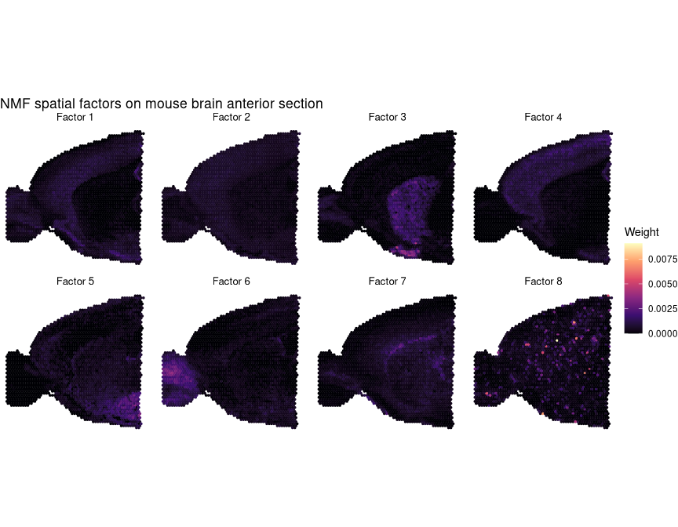

```r
k_opt <- nrow(H_brain)
n_show <- min(k_opt, 8)

spatial_df <- do.call(rbind, lapply(seq_len(n_show), function(f) {
  data.frame(
    x = xy[, 1], y = xy[, 2],
    weight = H_brain[f, ],
    factor = paste("Factor", f)
  )
}))
spatial_df$factor <- factor(spatial_df$factor,
                            levels = paste("Factor", seq_len(n_show)))

ggplot(spatial_df, aes(x, y, color = weight)) +
  geom_point(size = 0.6) +
  scale_color_viridis_c(option = "magma") +
  scale_y_reverse() +
  facet_wrap(~ factor, nrow = 2) +
  coord_equal() +
  theme_void() +
  theme(strip.text = element_text(size = 10, margin = margin(b = 3)),
        legend.position = "right") +
  labs(color = "Weight",
       title = "NMF spatial factors on mouse brain anterior section")
```

## Summary

| Example | Dataset | Key Feature | Metric |
| --- | --- | --- | --- |
| 1. Digits | 64 × 1797 | Part-based decomposition | CV loss, basis images |
| 2. MovieLens | 3867 × 610 | `mask_zeros`, CV | Test MSE on ratings |
| 3. Golub | 5000 × 38 | `guide_classifier`, CV | Accuracy (ALL/AML) |
| 4. CITE-seq | 2000 × 3000 | Semi-supervised | Accuracy (27 cell types) |
| 5. Multi-modal | RNA + ADT shared | `factor_shared` | Accuracy by modality |
| 6. Spatial | 2000 × 2696 | Tissue mapping | Spatial factor maps |

The `factor_net()` composable API handles diverse data types and analysis goals through a unified graph framework. Cross-validation, guides, and multi-modal integration are all orthogonal building blocks that combine fluently.